# Projeto Analise de Dados

Lucas Correia

17/10/2020

# Introdução

No-Show é uma expressão em ingles para pessoas que faltam a consultas medicas marcadas por qualquer razão. Fatores como idade, genero, distancia, tempo, salario, clima, esquecer/mudar o dia da consulta, problemas fisicos/psicologicos, tempo de espera para a consulta, etc., podem fazer com que o paciente não compareça a consulta no dia e horario marcado.

As consequencias da falta do paciente a consulta envolvem, mas nao se resume a: Pior tratamento do paciente, ineficiencia dos equipamentos e aumentar o tempo de espera de outros pacientes. Nos Estados Unidos, cerca de 62 consultas são perdidas por dia em hospitais comunitarios, o que acarreta em um prejuizo de 3 milhões de dolares ao ano.

Utilizando a base de dados do Kaggle, é possivel estudar as informações, verificar os motivos que levaram a falta do paciente e prever se o paciente irá faltar ou comparecer a consulta, permitindo os hospitais a preparar melhor seus agendamentos para os pacientes, diminuindo o tempo de espera da consulta.

# Preparação dos Dados

## Resumo

Os dados a serem utilizados estão disponiveis no Kaggle ([Link](https://www.kaggle.com/joniarroba/noshowappointments)), cujo proposito é tentar conseguir realizar previsão do paciente a consulta. Os dados possuem 110527 consultas marcadas entre os periodos de novembro de 2015 a junho de 2016 para serem realizadas entre o fim de abril de 2016 ao inicio de junho de 2016. Esse dataset possui um total de 14 caracteristicas.

```
## 'data.frame':    110527 obs. of  14 variables:
##  $ PatientId     : num  2.99e+13 5.59e+14 4.26e+12 8.68e+11 8.84e+12 ...
##  $ AppointmentID : int  5642903 5642503 5642549 5642828 5642494 5626772 5630279 5630575 5638447 5629123 ...
##  $ Gender        : Factor w/ 2 levels "F","M": 1 2 1 1 1 1 1 1 1 1 ...
##  $ ScheduledDay  : Factor w/ 103549 levels "2015-11-10T07:13:56Z",..: 27742 27504 27539 27709 27498 20074 21386 21496 24945 20895 ...
##  $ AppointmentDay: Factor w/ 27 levels "2016-04-29T00:00:00Z",..: 1 1 1 1 1 1 1 1 1 1 ...
##  $ Age           : int  62 56 62 8 56 76 23 39 21 19 ...
##  $ Neighbourhood : Factor w/ 81 levels "AEROPORTO","ANDORINHAS",..: 40 40 47 55 40 59 26 26 2 13 ...
##  $ Scholarship   : int  0 0 0 0 0 0 0 0 0 0 ...
##  $ Hipertension  : int  1 0 0 0 1 1 0 0 0 0 ...
##  $ Diabetes      : int  0 0 0 0 1 0 0 0 0 0 ...
##  $ Alcoholism    : int  0 0 0 0 0 0 0 0 0 0 ...
##  $ Handcap       : int  0 0 0 0 0 0 0 0 0 0 ...
##  $ SMS_received  : int  0 0 0 0 0 0 0 0 0 0 ...
##  $ No.show       : Factor w/ 2 levels "No","Yes": 1 1 1 1 1 1 2 2 1 1 ...
```

## Caracteristicas

### PatientId

A caracteristica *PatientId* é um identificador para o paciente da consulta. É o que permite saber se o paciente foi a mais de uma consulta no periodo de tempo.

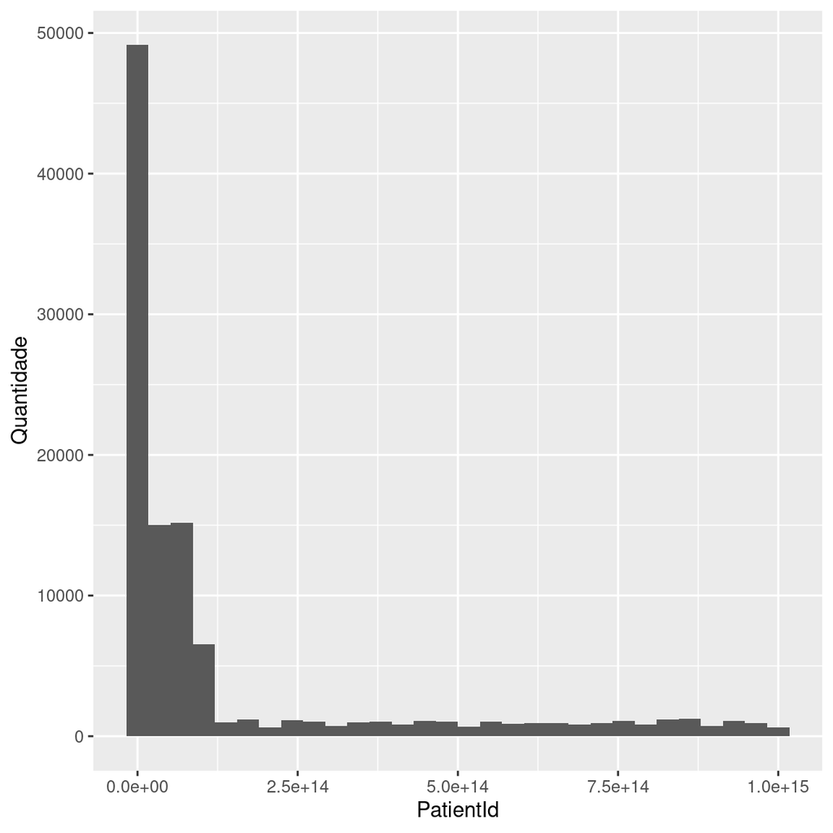

### AppointmentID

A caracteristica *AppointmentID* é um identificador da consulta. Ela é unica, não representando nada mais que se duas consultas são a mesma consulta.

### Gender

A caracteristica *Gender* representa o genero do paciente, se ele é do tipo masculino ou feminino.

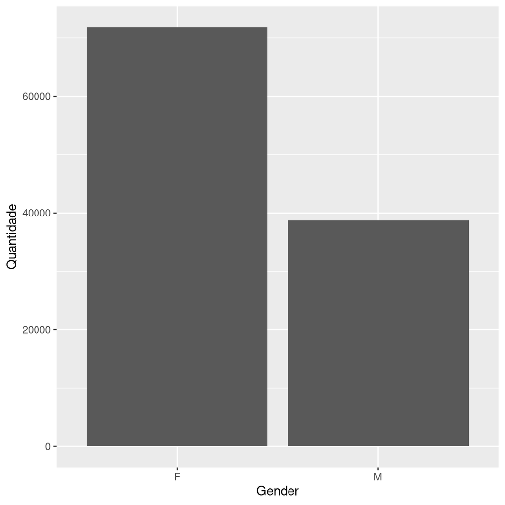

### ScheduledDay

A caracteristica *ScheduledDay* representa a data ao qual a consulta foi marcada.

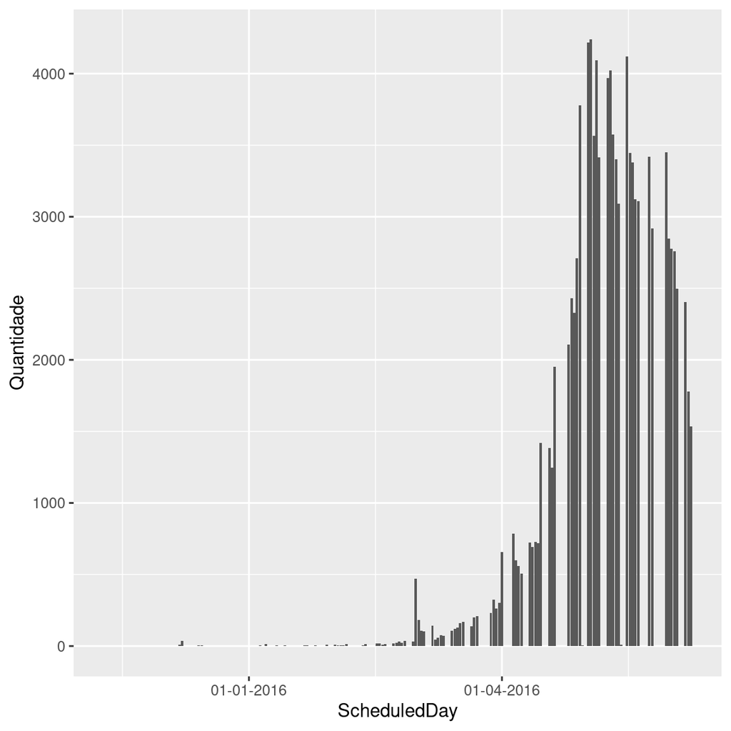

### AppointmentDay

A caracteristica *AppointmentDay* representa a data que será realizada a consulta do paciente.

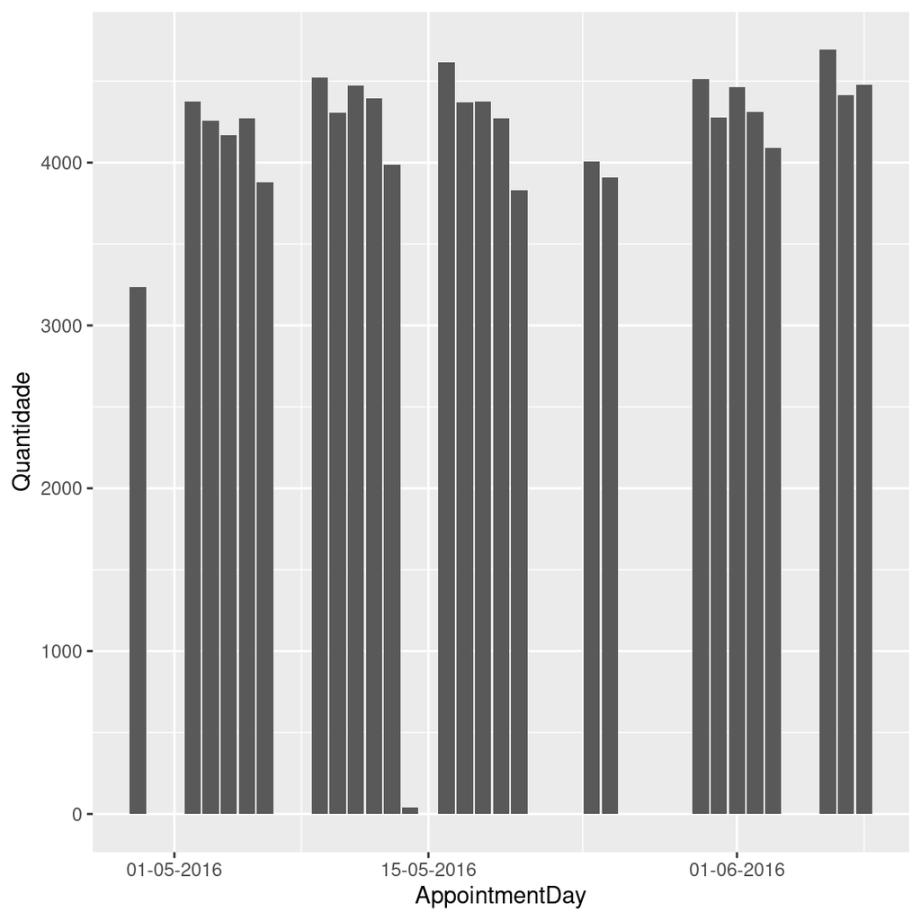

### Age

A caracteristica *Age* representa a idade do paciente.

[figure not shown]

### Neighbourhood

A caracteristica *Neighbourhood* representa o bairro ao qual a consulta será realizada.

[figure not shown]

### Scholarship

A caracteristica *Scholarship* representa se o paciente recebe algum tipo de bolsa/auxilio.

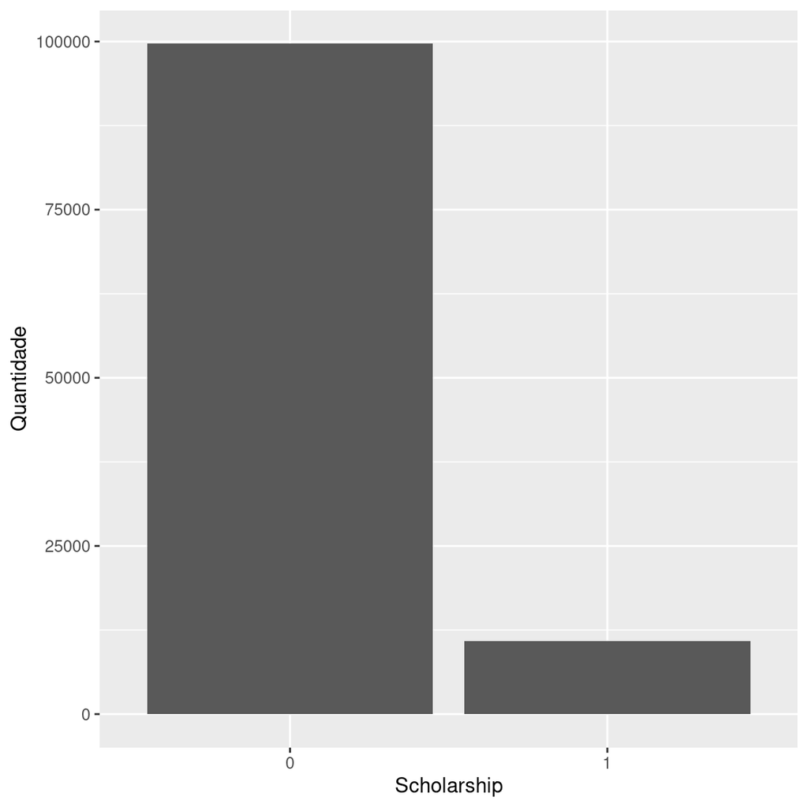

### Hipertension

A caracteristica *Hipertension* representa se o paciente possui hipertensão.

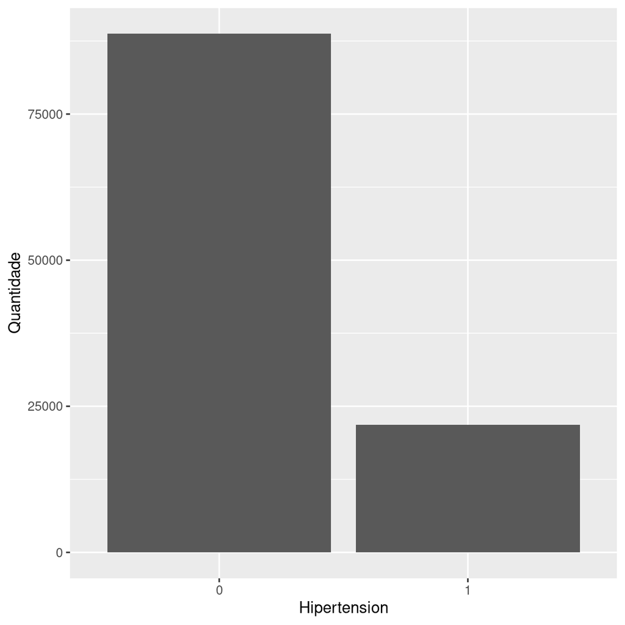

### Diabetes

A caracteistica *Diabetes* representa se o paciente possui diabetes.

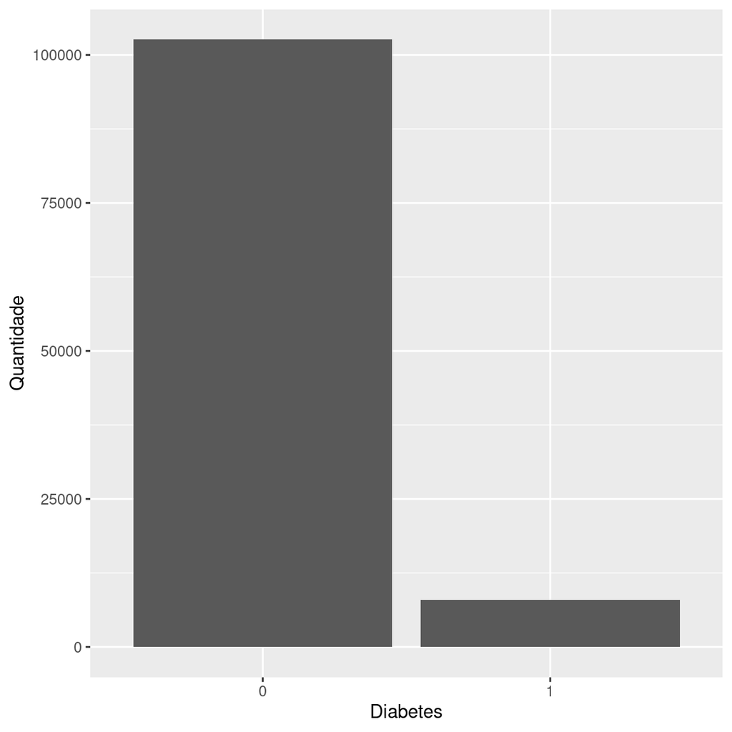

### Alcoholism

A caracteristica *Alcoholism* representa se o paciente é alcolatra.

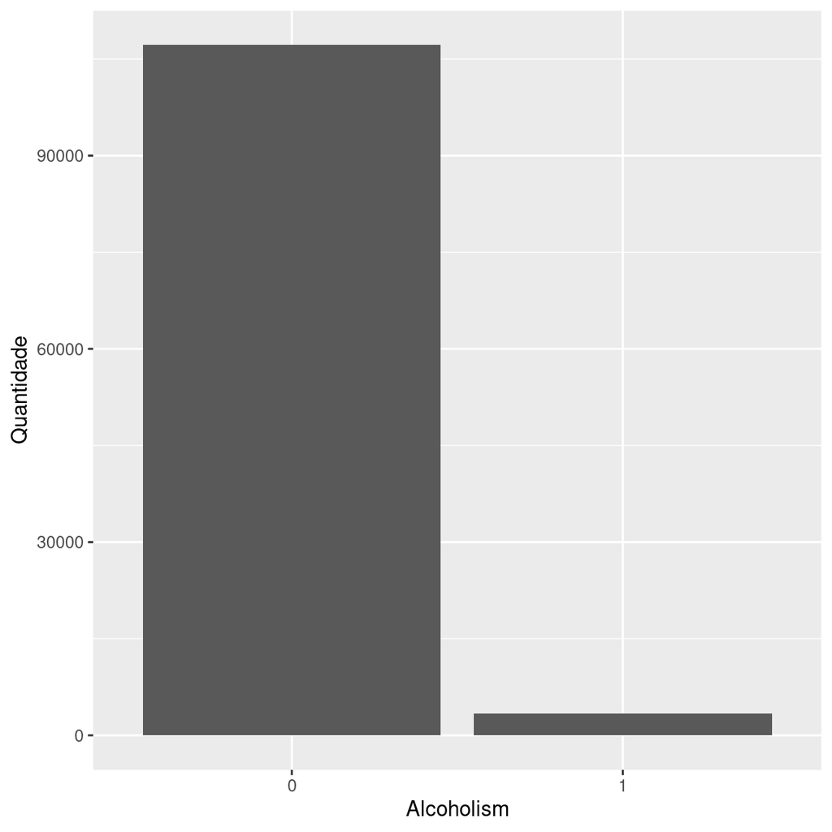

### Handcap

A caracteristica *handcap* representa se o paciente possui algum tipo de deficiencia.

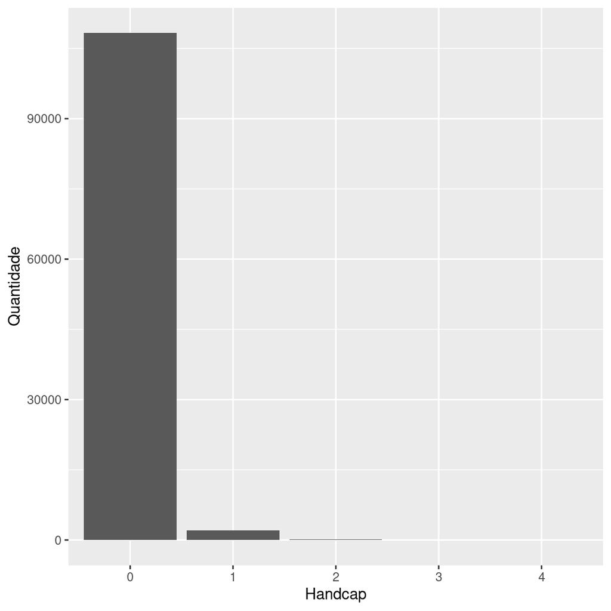